# PONK optimization

# Load the corpora

```r
library(tidyverse)
library(tidymodels)
library(jsonlite)
library(psych)
library(rstatix) # Wilcox effect size calculation
set.seed(42)

load_kuk_subcorpus_metadata <- function(crp) {
  read_tsv(paste(c(
    "../corpora/KUK_1.0/metadata/", crp, "_DocumentFileFormat.tsv"
  ), collapse = "")) %>%
    filter(FileFormat == "TXT") %>%
    full_join(
      read_tsv(paste(c(
        "../corpora/KUK_1.0/metadata/",
        crp,
        "_DocumentIdentificationGenreProperties.tsv"
      ), collapse = "")),
      by = "KUK_ID"
    ) %>%
    mutate(across(where(is.numeric), as.character)) %>%
    mutate(subcorpus = crp) %>%
    select(KUK_ID, FileName, FileFormat, FolderPath, subcorpus, everything())
}

kuky_orig <- fromJSON("../corpora/KUKY/argumentative.json")$documents %>%
  as_tibble() %>%
  bind_rows(
    fromJSON("../corpora/KUKY/normative.json")$documents %>% as_tibble()
  ) %>%
  rename(KUK_ID = doc_id) %>%
  select(!c(plainText, doc_name)) %>%
  select(KUK_ID, everything())

kuky_kuk <- load_kuk_subcorpus_metadata("KUKY") %>%
  filter(FolderPath == "data/KUKY/TXT") %>%
  select(!c(Anonymized, RecipientType, RecipientIndividuation, AuthorType, Objectivity, LegalActType, Bindingness))
kuky <- kuky_kuk %>% full_join(kuky_orig, by = "KUK_ID") %>%
  # filter out court decisions
  filter(!(KUK_ID %in% c(
    "671a2e57c6537d54ff0626ed",
    "671a2e57c6537d54ff0626ee",
    "671a2e57c6537d54ff0626ef",
    "67476b48c6537d54ff063934",
    "67476b48c6537d54ff063935",
    "67476b48c6537d54ff063936",
    "67476b48c6537d54ff063937",
    "67476b48c6537d54ff06393e",
    "67476b48c6537d54ff06393c",
    "67476b48c6537d54ff06393b",
    "67476b48c6537d54ff063941",
    "67476b48c6537d54ff063944",
    "677e929cc6537d54ff06509c",
    "67843083c6537d54ff06516b",
    "67843083c6537d54ff06516c",
    "67843083c6537d54ff06516d",
    "67843084c6537d54ff06516e",
    "67843084c6537d54ff06516f",
    "67843084c6537d54ff065171",
    "67843084c6537d54ff065170",
    "678430cbc6537d54ff065173",
    "678563ecc6537d54ff0651bc",
    "678563ecc6537d54ff0651bd",
    "678563edc6537d54ff0651be",
    "678563edc6537d54ff0651bf",
    "678563edc6537d54ff0651c0",
    "678563edc6537d54ff0651c2",
    "678563edc6537d54ff0651c1",
    "678563edc6537d54ff0651c4",
    "678563edc6537d54ff0651c5",
    "678563edc6537d54ff0651c3",
    "678563edc6537d54ff0651c6",
    "678563edc6537d54ff0651c8",
    "678563edc6537d54ff0651c7",
    "678563edc6537d54ff0651c9",
    "67895a5bc6537d54ff065612",
    "67895a5bc6537d54ff065613",
    "67895a5bc6537d54ff065614",
    "67895a5bc6537d54ff065615",
    "67895a5bc6537d54ff065616",
    "674465a7c6537d54ff06315a",
    "674465a7c6537d54ff06315b",
    "674465a7c6537d54ff06315c",
    "674465a7c6537d54ff06315d",
    "674465a7c6537d54ff06315e",
    "674465a7c6537d54ff06315f",
    "674465a7c6537d54ff063160",
    "674465a7c6537d54ff063161",
    "671a2e57c6537d54ff0626ec"
  )))

eso <- load_kuk_subcorpus_metadata("ESO")
frbo <- load_kuk_subcorpus_metadata("FrBo") %>%
  # load metadata for FrBo updated with Quality (=Readability)
  bind_rows(
    read_csv("../corpora/FrBo_contents.csv") %>%
      mutate(Readability = str_to_lower(Quality)) %>%
      mutate(across(c(Readability), ~ str_replace(.x, "good", "high"))) %>%
      select(!Quality)
  ) %>%
  # and move the Quality values to the original rows
  arrange(KUK_ID) %>%
  group_by(KUK_ID) %>%
  fill(Readability, .direction = "up") %>%
  ungroup() %>%
  filter(!is.na(FileName))
lifrlaw <- load_kuk_subcorpus_metadata("LiFRLaw")
ombuflyers <- load_kuk_subcorpus_metadata("OmbuFlyers")
df <- kuky %>%
  bind_rows(eso) %>%
  bind_rows(frbo) %>%
  bind_rows(lifrlaw) %>%
  bind_rows(ombuflyers)

str(df)
```

```
## tibble [6,244 × 21] (S3: tbl_df/tbl/data.frame)
##  $ KUK_ID                : chr [1:6244] "671918e2c6537d54ff0626db" "671918e2c6537d54ff0626dc" "671918e2c6537d54ff0626dd" "671918e2c6537d54ff0626de" ...
##  $ FileName              : chr [1:6244] "orig_Certifikáty autorizovaných inspektorů" "red_Co je to územní plánování_final_přidat odkaz na manuál o RP až bude" "orig_financovani_politickych_stran" "Duchody" ...
##  $ FileFormat            : chr [1:6244] "TXT" "TXT" "TXT" "TXT" ...
##  $ FolderPath            : chr [1:6244] "data/KUKY/TXT" "data/KUKY/TXT" "data/KUKY/TXT" "data/KUKY/TXT" ...
##  $ subcorpus             : chr [1:6244] "KUKY" "KUKY" "KUKY" "KUKY" ...
##  $ SourceDB              : chr [1:6244] "SourceDB" "SourceDB" "SourceDB" "SourceDB" ...
##  $ SourceID              : chr [1:6244] NA NA NA NA ...
##  $ DocumentTitle         : chr [1:6244] NA NA NA NA ...
##  $ ClarityPursuit        : logi [1:6244] NA NA NA NA NA NA ...
##  $ Readability           : chr [1:6244] "low" "high" "low" "low" ...
##  $ SyllogismBased        : chr [1:6244] "false" "false" "false" "false" ...
##  $ DocumentVersion       : chr [1:6244] "Original" "Redesign" "Original" "Original" ...
##  $ ParentDocumentID      : chr [1:6244] NA NA NA NA ...
##  $ LegalActType          : chr [1:6244] "normative" "normative" "normative" "normative" ...
##  $ Objectivity           : chr [1:6244] "quasiobjective" "quasiobjective" "quasiobjective" "quasiobjective" ...
##  $ Bindingness           : logi [1:6244] FALSE FALSE FALSE FALSE FALSE FALSE ...
##  $ AuthorType            : chr [1:6244] "individual" "individual" "individual" "authority" ...
##  $ RecipientType         : chr [1:6244] "natural person" "natural person" "natural person" "natural person" ...
##  $ RecipientIndividuation: chr [1:6244] "public" "public" "public" "public" ...
##  $ Anonymized            : chr [1:6244] "No" "No" "No" "No" ...
##  $ Recipient Type        : chr [1:6244] NA NA NA NA ...
```

# Filter out duplicates

Some subcorpora overlap (*FrBo* with *ESO*, and multiple subcorpora with *KUKY*).

The usage of documents with ClarityPursuit == NA is questionable, let’s exclude such documents. This effectively comes with a price of excluding the whole *ESO* subcorpus, even though some of its documents are available in *KUKY*.

The usage of documents with ClarityPursuit == TRUE is also questionable as they’re not reviewed in the same manner as the documents from KUKY, yet at the same time they are less likely to be as “unreadable” as the documents with ClarityPursuit == FALSE. Such documents could very well be readable, interfering with the training process.

After filtering ClarityPursuit == NA out, the only remaining overlaps are with *KUKY*. Let’s keep the documents from *KUKY* as they are associated with a more careful readability evaluation.

```r
table(df$subcorpus, df$ClarityPursuit, useNA = "ifany")
```

```
##
##              FALSE TRUE <NA>
##   ESO            0    0 5615
##   FrBo         114  205    0
##   KUKY           0    0  175
##   LiFRLaw        6   12    0
##   OmbuFlyers    52   65    0
```

```r
table(df$ClarityPursuit, df$Readability, df$subcorpus, useNA = "ifany")
```

```
## , ,  = ESO
##
##
##         high  low medium <NA>
##   FALSE    0    0      0    0
##   TRUE     0    0      0    0
##   <NA>     0    0      0 5615
##
## , ,  = FrBo
##
##
##         high  low medium <NA>
##   FALSE   51    0     54    9
##   TRUE   188    0     17    0
##   <NA>     0    0      0    0
##
## , ,  = KUKY
##
##
##         high  low medium <NA>
##   FALSE    0    0      0    0
##   TRUE     0    0      0    0
##   <NA>   113   36     26    0
##
## , ,  = LiFRLaw
##
##
##         high  low medium <NA>
##   FALSE    0    0      0    6
##   TRUE     0    0      0   12
##   <NA>     0    0      0    0
##
## , ,  = OmbuFlyers
##
##
##         high  low medium <NA>
##   FALSE    0    0      0   52
##   TRUE     0    0      0   65
##   <NA>     0    0      0    0
```

```r
# display duplicate file entries
df %>%
  group_by(FileName) %>%
  mutate(n = n()) %>%
  filter(n > 1) %>%
  select(FileName, subcorpus, Readability, ClarityPursuit) %>%
  arrange(FileName) %>%
  print(n = 80)
```

```
## # A tibble: 80 × 4
## # Groups:   FileName [40]
##    FileName                                 subcorpus Readability ClarityPursuit
##    <chr>                                    <chr>     <chr>       <lgl>
##  1 100                                      ESO       <NA>        NA
##  2 100                                      FrBo      high        TRUE
##  3 102                                      ESO       <NA>        NA
##  4 102                                      FrBo      high        TRUE
##  5 110                                      ESO       <NA>        NA
##  6 110                                      FrBo      medium      TRUE
##  7 14                                       ESO       <NA>        NA
##  8 14                                       FrBo      high        TRUE
##  9 142                                      ESO       <NA>        NA
## 10 142                                      FrBo      medium      TRUE
## 11 148                                      ESO       <NA>        NA
```

[output cut: 69 more lines]

```r
# search for FrBo duplicates
df_frbo_duplicates <- df %>%
  filter(str_detect(FileName, "red_|orig_")) %>%
  mutate(new_fname = str_remove(FileName, "^[0-9]{3}_")) %>%
  group_by(new_fname) %>%
  mutate(n = n()) %>%
  ungroup() %>%
  filter(n >= 2)

all_frbo_duplicates <- df_frbo_duplicates %>% pull(FileName)

df_frbo_dup_wide <- df_frbo_duplicates %>%
  select(new_fname, subcorpus, Readability, n) %>%
  distinct(new_fname, subcorpus, Readability, n) %>%
  pivot_wider(
    names_from = subcorpus,
    values_from = Readability,
    names_prefix = "Readability_"
  ) %>%
  mutate(
    class_KUKY = as.factor(if_else(Readability_KUKY == "high", "good", "bad")),
    class_FrBo = as.factor(if_else(Readability_FrBo == "high", "good", "bad"))
  )

table(
  df_frbo_dup_wide$Readability_KUKY, df_frbo_dup_wide$Readability_FrBo,
  useNA = "ifany"
)
```

```
##
##          high medium <NA>
##   high     15      0    0
##   low       7      5    1
##   medium    1      0    0
```

```r
readability_agreement <- df_frbo_dup_wide %>%
  select(class_KUKY, class_FrBo) %>%
  table()
readability_agreement
```

```
##           class_FrBo
## class_KUKY bad good
##       bad    5    8
##       good   0   15
```

```r
cohen.kappa(readability_agreement)
```

```
## Call: cohen.kappa1(x = x, w = w, n.obs = n.obs, alpha = alpha, levels = levels,
##     w.exp = w.exp)
##
## Cohen Kappa and Weighted Kappa correlation coefficients and confidence boundaries
##                  lower estimate upper
## unweighted kappa  0.12      0.4  0.68
## weighted kappa    0.12      0.4  0.68
##
##  Number of subjects = 28
```

```r
# this is valid UNDER THE CONDITION that we construct the "good" class
# out of high-readability texts only
good_frbo_duplicates <- df_frbo_dup_wide %>%
  filter(
    Readability_KUKY == Readability_FrBo | (
      (Readability_KUKY == "medium" | Readability_KUKY == "low") &
        (Readability_FrBo == "medium")
    )
  ) %>%
  pull(new_fname)

bad_frbo_duplicates <- setdiff(all_frbo_duplicates, good_frbo_duplicates)

# remove FrBo/articles-originated texts from KUKY because:
#   1. they are duplicates
#   2. they are actually represented in markdown
df %>%
  filter(subcorpus == "KUKY" & str_detect(FileName, "red_|orig_")) %>%
  pull(FileName)
```

```
##  [1] "orig_Certifikáty autorizovaných inspektorů"
##  [2] "red_Co je to územní plánování_final_přidat odkaz na manuál o RP až bude"
##  [3] "orig_financovani_politickych_stran"
##  [4] "003_red_Jak dosáhnout změny dopravního značení_final"
##  [5] "015_orig_Jak komunikovat s úřady elektronicky"
##  [6] "021_red_Jak daleko od hranice pozemku musí být umístěno elektrické vedení"
##  [7] "013_orig_10 významných práv účastníka správního řízení"
##  [8] "020_red_Jak chránit vody a správně s nimi nakládat_revKZ"
##  [9] "030_orig_Co je to a jak probíhá integrované povolování_final"
## [10] "018_red_Co je to úřední deska a jak ji využít"
## [11] "012_orig_Jak chránit vody a správně s nimi nakládat_revKZ"
## [12] "010_red_Guerilla gardening, jak zahradničit na veřejném prostranství (ne)legálně_final"
## [13] "014_red_Co je to a jak probíhá integrované povolování_final"
## [14] "031_orig_Co je to EIA_final"
## [15] "023_red_Co dělat, když soused postavil černou stvabu_final, bacha na infrgafiku"
## [16] "029_orig_Certifikáty autorizovaných inspektorů"
## [17] "032_orig_Co je to úřední deska a jak ji využít"
## [18] "026_orig_Jak jedná spolek navenek"
## [19] "041_red_Hlukové limity a udělování výjimek_prefinal"
## [20] "027_orig_Jak dosáhnout odpovědnosti úředníka za škodu"
## [21] "038_orig_Co je to korupce a klientelismus"
## [22] "025_red_GDPR Jak právo chrání osobní údaje_final"
## [23] "028_orig_Co dělat, když soused postavil černou stvabu_final, bacha na infrgafiku"
## [24] "034_red_Jak dosáhnout zrušení stanoviska EIA_final"
## [25] "036_red_Dotčený vlastník - Kdo to je a jaká má v územním plánování práva_final"
## [26] "059_red_10 významných práv účastníka správního řízení"
## [27] "044_red_financovani_politickych_stran úprava 2021"
## [28] "053_orig_Guerilla gardening, jak zahradničit na veřejném prostranství (ne)legálně_final"
## [29] "051_orig_Co je to regulační plán a jak dosáhnout jeho přijetí_původní"
## [30] "049_red_CO je černá stvaba a jak ji ponat"
```

```r
df <- df %>%
  filter(subcorpus != "KUKY" | !str_detect(FileName, "red_|orig_"))

# remove FrBo articles with different readability assessments by KUKY and FrBo
df <- df %>% filter(!(FileName %in% bad_frbo_duplicates))

# these two are also duplicates
df <- df %>%
  filter(!(FileName %in% c(
    "orig_Mohou spolky ve správních žalobách používat věcné argumenty_final, odkaz na soudní ochrana spolků",
    "red_Mohou spolky ve správních žalobách používat věcné argumenty_final, odkaz na soudní ochrana spolků"
  ))) %>%
  # missing in real data
  filter(FileName != "partred_Jak chránit vody a správně s nimi nakládat")

# remove OmbuFlyer–KUKY duplicates with different names
# keep the ones from KUKY
bad_of_kuky_duplicates <- df %>%
  filter(subcorpus %in% c("KUKY", "OmbuFlyers")) %>%
  mutate(new_fname = str_remove(FileName, "^[0-9]{3}_")) %>%
  group_by(new_fname) %>%
  mutate(n = n()) %>%
  ungroup() %>%
  filter(n > 1 & subcorpus == "OmbuFlyers") %>%
  select(!c(new_fname, n)) %>%
  pull(KUK_ID)
bad_of_kuky_duplicates
```

```
##  [1] "ombuflyer_0008" "ombuflyer_0012" "ombuflyer_0016" "ombuflyer_0021"
##  [5] "ombuflyer_0023" "ombuflyer_0025" "ombuflyer_0027" "ombuflyer_0028"
##  [9] "ombuflyer_0035" "ombuflyer_0036" "ombuflyer_0041" "ombuflyer_0045"
## [13] "ombuflyer_0047" "ombuflyer_0051" "ombuflyer_0054" "ombuflyer_0058"
## [17] "ombuflyer_0060" "ombuflyer_0062" "ombuflyer_0064" "ombuflyer_0105"
```

```r
df <- df %>% filter(!(KUK_ID %in% bad_of_kuky_duplicates))

# keep only rows where either Readability or ClarityPursuit isn't NA
# and exclude ClarityPursuit == TRUE
df <- df %>%
  filter(!is.na(Readability) | ClarityPursuit == FALSE)

# 6 duplicates remaining
# keep the ones from KUKY as they have a readability assessment (see above)
df <- df %>%
  group_by(FileName) %>%
  mutate(n = n()) %>%
  ungroup() %>%
  filter(n == 1 | subcorpus == "KUKY") %>%
  select(!n)

df
```

```
## # A tibble: 493 × 21
##    KUK_ID             FileName FileFormat FolderPath subcorpus SourceDB SourceID
##    <chr>              <chr>    <chr>      <chr>      <chr>     <chr>    <chr>
##  1 671918e2c6537d54f… Duchody  TXT        data/KUKY… KUKY      SourceDB <NA>
##  2 671918e2c6537d54f… Odpadni… TXT        data/KUKY… KUKY      SourceDB <NA>
##  3 673b7a37c6537d54f… 002_Kom… TXT        data/KUKY… KUKY      SourceDB <NA>
##  4 673b7a37c6537d54f… 006_Chc… TXT        data/KUKY… KUKY      SourceDB <NA>
##  5 673b7a37c6537d54f… 004_Nev… TXT        data/KUKY… KUKY      SourceDB <NA>
##  6 673b7a37c6537d54f… 008_Pol… TXT        data/KUKY… KUKY      SourceDB <NA>
##  7 673b7a37c6537d54f… 005_Och… TXT        data/KUKY… KUKY      SourceDB <NA>
##  8 673b7a37c6537d54f… 016_Obc… TXT        data/KUKY… KUKY      SourceDB <NA>
##  9 673b7a37c6537d54f… 019_Dět… TXT        data/KUKY… KUKY      SourceDB <NA>
## 10 673b7a37c6537d54f… 007_DŮC… TXT        data/KUKY… KUKY      SourceDB <NA>
## # ℹ 483 more rows
## # ℹ 14 more variables: DocumentTitle <chr>, ClarityPursuit <lgl>,
## #   Readability <chr>, SyllogismBased <chr>, DocumentVersion <chr>,
## #   ParentDocumentID <chr>, LegalActType <chr>, Objectivity <chr>,
## #   Bindingness <lgl>, AuthorType <chr>, RecipientType <chr>,
## #   RecipientIndividuation <chr>, Anonymized <chr>, `Recipient Type` <chr>
```

# Classes

```r
table(df$subcorpus, df$Readability, useNA = "ifany")
```

```
##
##              high low medium <NA>
##   FrBo        229   0     71    7
##   KUKY         98  22     25    0
##   LiFRLaw       0   0      0    3
##   OmbuFlyers    0   0      0   38
```

```r
df <- df %>%
  mutate(class = if_else(Readability %in% c("high"), "good", "bad"))

df %>%
  select(class) %>%
  table()
```

```
## class
##  bad good
##  166  327
```

```r
df %>%
  select(subcorpus, class) %>%
  table()
```

```
##             class
## subcorpus    bad good
##   FrBo        78  229
##   KUKY        47   98
##   LiFRLaw      3    0
##   OmbuFlyers  38    0
```

# Measurements

```r
meas <- read_csv("../measurements/measurements_2025-12-02.csv") %>%
  filter(KUK_ID %in% df$KUK_ID)
.firstnonmetacolumn <- 17

data_no_nas <- meas %>%
  select(!c(
    fpath,
    # KUK_ID,
    # FileName,
    FolderPath,
    # subcorpus,
    DocumentTitle,
    ClarityPursuit,
    Readability,
    SyllogismBased,
    SourceDB
  )) %>%
  # replace -1s in variation coefficients with NAs
  mutate(across(c(
    `RuleDoubleAdpos.max_allowable_distance.v`,
    `RuleTooManyNegations.max_negation_frac.v`,
    `RuleTooManyNegations.max_allowable_negations.v`,
    `RuleTooManyNominalConstructions.max_noun_frac.v`,
    `RuleTooManyNominalConstructions.max_allowable_nouns.v`,
    `RuleCaseRepetition.max_repetition_count.v`,
    `RuleCaseRepetition.max_repetition_frac.v`,
    `RulePredSubjDistance.max_distance.v`,
    `RulePredObjDistance.max_distance.v`,
    `RuleInfVerbDistance.max_distance.v`,
    `RuleMultiPartVerbs.max_distance.v`,
    `RuleLongSentences.max_length.v`,
    `RulePredAtClauseBeginning.max_order.v`,
    `mattr.v`,
    `maentropy.v`
  ), ~ na_if(.x, -1))) %>%
  # replace NAs with 0s
  replace_na(list(
    RuleGPcoordovs = 0,
    RuleGPdeverbaddr = 0,
    RuleGPpatinstr = 0,
    RuleGPdeverbsubj = 0,
    RuleGPadjective = 0,
    RuleGPpatbenperson = 0,
    RuleGPwordorder = 0,
    RuleDoubleAdpos = 0,
    RuleDoubleAdpos.max_allowable_distance.v = 0,
    RuleAmbiguousRegards = 0,
    RuleReflexivePassWithAnimSubj = 0,
    RuleTooManyNegations = 0,
    RuleTooManyNegations.max_negation_frac.v = 0,
    RuleTooManyNegations.max_allowable_negations.v = 0,
    RuleTooManyNominalConstructions.max_noun_frac.v = 0,
    RuleTooManyNominalConstructions.max_allowable_nouns.v = 0,
    RuleFunctionWordRepetition = 0,
    RuleCaseRepetition.max_repetition_count.v = 0,
    RuleCaseRepetition.max_repetition_frac.v = 0,
    RuleWeakMeaningWords = 0,
    RuleAbstractNouns = 0,
    RuleRelativisticExpressions = 0,
    RuleConfirmationExpressions = 0,
    RuleRedundantExpressions = 0,
    RuleTooLongExpressions = 0,
    RuleAnaphoricReferences = 0,
    RuleLiteraryStyle = 0,
    RulePassive = 0,
    RulePredSubjDistance = 0,
    RulePredSubjDistance.max_distance.v = 0,
    RulePredObjDistance = 0,
    RulePredObjDistance.max_distance.v = 0,
    RuleInfVerbDistance = 0,
    RuleInfVerbDistance.max_distance.v = 0,
    RuleMultiPartVerbs = 0,
    RuleMultiPartVerbs.max_distance.v = 0,
    RuleLongSentences.max_length.v = 0,
    RulePredAtClauseBeginning.max_order.v = 0,
    RuleVerbalNouns = 0,
    RuleDoubleComparison = 0,
    RuleWrongValencyCase = 0,
    RuleWrongVerbonominalCase = 0,
    RuleIncompleteConstruction = 0
  )) %>%
  # norm data expected to correlate with text length
  mutate(across(c(
    RuleGPcoordovs,
    RuleGPdeverbaddr,
    RuleGPpatinstr,
    RuleGPdeverbsubj,
    RuleGPadjective,
    RuleGPpatbenperson,
    RuleGPwordorder,
    RuleDoubleAdpos,
    RuleAmbiguousRegards,
    RuleFunctionWordRepetition,
    RuleWeakMeaningWords,
    RuleAbstractNouns,
    RuleRelativisticExpressions,
    RuleConfirmationExpressions,
    RuleRedundantExpressions,
    RuleTooLongExpressions,
    RuleAnaphoricReferences,
    RuleLiteraryStyle,
    RulePassive,
    RuleVerbalNouns,
    RuleDoubleComparison,
    RuleWrongValencyCase,
    RuleWrongVerbonominalCase,
    RuleIncompleteConstruction,
    num_hapax,
    RuleReflexivePassWithAnimSubj,
    RuleTooManyNominalConstructions,
    RulePredSubjDistance,
    RuleMultiPartVerbs,
    RulePredAtClauseBeginning
  ), ~ .x / word_count)) %>%
  mutate(across(c(
    RuleTooFewVerbs,
    RuleTooManyNegations,
    RuleCaseRepetition,
    RuleLongSentences,
    RulePredObjDistance,
    RuleInfVerbDistance
  ), ~ .x / sent_count)) %>%
  # replace NAs with medians
  mutate(across(c(
    RuleDoubleAdpos.max_allowable_distance,
    RuleTooManyNegations.max_negation_frac,
    RuleTooManyNegations.max_allowable_negations,
    RulePredSubjDistance.max_distance,
    RulePredObjDistance.max_distance,
    RuleInfVerbDistance.max_distance,
    RuleMultiPartVerbs.max_distance
  ), ~ coalesce(., median(., na.rm = TRUE))))

data_clean <- data_no_nas %>%
  # remove variables identified as text-length dependent
  select(!c(
    RuleTooFewVerbs,
    RuleTooManyNegations,
    RuleTooManyNominalConstructions,
    RuleCaseRepetition,
    RuleLongSentences,
    RulePredAtClauseBeginning,
    syllab_count,
    char_count
  )) %>%
  # remove variables identified as unreliable
  select(!c(
    RuleAmbiguousRegards,
    RuleFunctionWordRepetition,
    RuleDoubleComparison,
    RuleWrongValencyCase,
    RuleWrongVerbonominalCase
  )) %>%
  # remove further variables belonging to the 'acceptability' category
  select(!c(RuleIncompleteConstruction)) %>%
  # remove artificially limited variables
  select(!c(
    RuleCaseRepetition.max_repetition_frac,
    RuleCaseRepetition.max_repetition_frac.v
  )) %>%
  # remove variables with too many NAs
  # select(!c(
  #   RuleDoubleAdpos.max_allowable_distance,
  #   RuleDoubleAdpos.max_allowable_distance.v
  # )) %>%
  mutate(across(c(
    class,
    FileFormat,
    subcorpus,
    DocumentVersion,
    LegalActType,
    Objectivity,
    AuthorType,
    RecipientType,
    RecipientIndividuation,
    Anonymized
  ), ~ as.factor(.x)))
```

# Intervals

```r
intervals <- tibble(
  feat = character(),
  type = character(),
  minimum = numeric(),
  maximum = numeric(),
)
effects <- tibble(
  feat = character(),
  p_val = numeric(),
  effsize = numeric()
)
variable_polarity <- c()

for (variab in names(data_clean)[.firstnonmetacolumn:ncol(data_clean)]) {
  cat(variab, "\n")

  effects <- effects %>% add_row(
    feat = variab,
    p_val = wilcox_test(data_clean, reformulate("class", variab))[["p"]],
    effsize = wilcox_effsize(
      data_clean, reformulate("class", variab)
    )[["effsize"]][[1]]
  )

  distr_good <- data_clean %>%
    filter(class == "good") %>%
    pull({{ variab }})
  distr_bad <- data_clean %>%
    filter(class == "bad") %>%
    pull({{ variab }})

  positive <- mean(distr_good) > mean(distr_bad)
  variable_polarity[variab] <- positive

  quant_good <- quantile(distr_good, probs = c(0.25, 0.75), names = FALSE)
  quant_bad <- quantile(distr_bad, probs = c(0.25, 0.75), names = FALSE)
  borders <- sort(c(quant_good, quant_bad))[2:3]

  if (
    (quant_good[1] < quant_bad[1] & quant_good[2] > quant_bad[2]) |
      (quant_good[1] > quant_bad[1] & quant_good[2] < quant_bad[2])) {
    cat(variab, "not determinative\n")
  } else if (positive) {
    intervals <- intervals %>%
      add_row(
        feat = variab,
        type = "bad",
        minimum = -Inf,
        maximum = borders[1]
      ) %>%
      add_row(
        feat = variab,
        type = "medium",
        minimum = borders[1],
        maximum = borders[2]
      ) %>%
      add_row(
        feat = variab,
        type = "good",
        minimum = borders[2],
        maximum = Inf
      )
  } else {
    intervals <- intervals %>%
      add_row(
        feat = variab,
        type = "good",
        minimum = -Inf,
        maximum = borders[1]
      ) %>%
      add_row(
        feat = variab,
        type = "medium",
        minimum = borders[1],
        maximum = borders[2]
      ) %>%
      add_row(
        feat = variab,
        type = "bad",
        minimum = borders[2],
        maximum = Inf
      )
  }
}
```

```
## RuleAbstractNouns
## RuleAnaphoricReferences
## RuleCaseRepetition.max_repetition_count
## RuleCaseRepetition.max_repetition_count.v
## RuleConfirmationExpressions
## RuleDoubleAdpos
## RuleDoubleAdpos.max_allowable_distance
## RuleDoubleAdpos.max_allowable_distance.v
## RuleGPadjective
## RuleGPcoordovs
## RuleGPdeverbaddr
## RuleGPdeverbsubj
## RuleGPpatbenperson
## RuleGPpatinstr
## RuleGPwordorder
## RuleInfVerbDistance
## RuleInfVerbDistance.max_distance
## RuleInfVerbDistance.max_distance not determinative
## RuleInfVerbDistance.max_distance.v
## RuleLiteraryStyle
## RuleLongSentences.max_length
## RuleLongSentences.max_length.v
## RuleMultiPartVerbs
## RuleMultiPartVerbs not determinative
## RuleMultiPartVerbs.max_distance
## RuleMultiPartVerbs.max_distance.v
## RulePassive
## RulePredAtClauseBeginning.max_order
## RulePredAtClauseBeginning.max_order.v
## RulePredObjDistance
## RulePredObjDistance.max_distance
## RulePredObjDistance.max_distance.v
## RulePredObjDistance.max_distance.v not determinative
## RulePredSubjDistance
## RulePredSubjDistance.max_distance
## RulePredSubjDistance.max_distance.v
## RuleRedundantExpressions
## RuleReflexivePassWithAnimSubj
## RuleRelativisticExpressions
## RuleTooFewVerbs.min_verb_frac
```

[output cut: 18 more lines]

```
## fkgl
## fre
## gf
## hpoint
## maentropy
## maentropy.v
## mamr
## mattr
## mattr.v
## num_hapax
## sent_count
## smog
## ttr
## verb_dist
## word_count
```

```r
intervals %>% write_csv("intervals_2025-12-02.csv")

effects %>%
  arrange(p_val) %>%
  print(n = 100)
```

```
## # A tibble: 69 × 3
##    feat                                                     p_val effsize
##    <chr>                                                    <dbl>   <dbl>
##  1 RuleLiteraryStyle                                     5.63e-10 0.279
##  2 activity                                              5.52e- 8 0.245
##  3 verb_dist                                             6.56e- 8 0.243
##  4 RuleTooManyNominalConstructions.max_allowable_nouns   6.60e- 8 0.243
##  5 ari                                                   1.21e- 6 0.219
##  6 maentropy                                             3.09e- 6 0.210
##  7 RuleLongSentences.max_length                          5.71e- 6 0.204
##  8 mattr                                                 5.76e- 6 0.204
##  9 RuleCaseRepetition.max_repetition_count.v             6.58e- 6 0.203
## 10 smog                                                  1.37e- 5 0.196
## 11 fkgl                                                  1.77e- 5 0.193
## 12 gf                                                    3.7 e- 5 0.186
```

[output cut: 57 more lines]

```r
intervals %>%
  print(n = 1000)
```

```
## # A tibble: 195 × 4
##     feat                                              type     minimum   maximum
##     <chr>                                             <chr>      <dbl>     <dbl>
##   1 RuleAbstractNouns                                 good  -Inf         9.63e-4
##   2 RuleAbstractNouns                                 medi…    9.63e-4   3.94e-3
##   3 RuleAbstractNouns                                 bad      3.94e-3 Inf
##   4 RuleAnaphoricReferences                           bad   -Inf         0
##   5 RuleAnaphoricReferences                           medi…    0         6.59e-4
##   6 RuleAnaphoricReferences                           good     6.59e-4 Inf
##   7 RuleCaseRepetition.max_repetition_count           good  -Inf         1.37e+0
##   8 RuleCaseRepetition.max_repetition_count           medi…    1.37e+0   1.46e+0
##   9 RuleCaseRepetition.max_repetition_count           bad      1.46e+0 Inf
##  10 RuleCaseRepetition.max_repetition_count.v         good  -Inf         4.68e-1
##  11 RuleCaseRepetition.max_repetition_count.v         medi…    4.68e-1   5.19e-1
##  12 RuleCaseRepetition.max_repetition_count.v         bad      5.19e-1 Inf
```

[output cut: 183 more lines]

# Boxplots

```
## boxplot RuleAbstractNouns
```

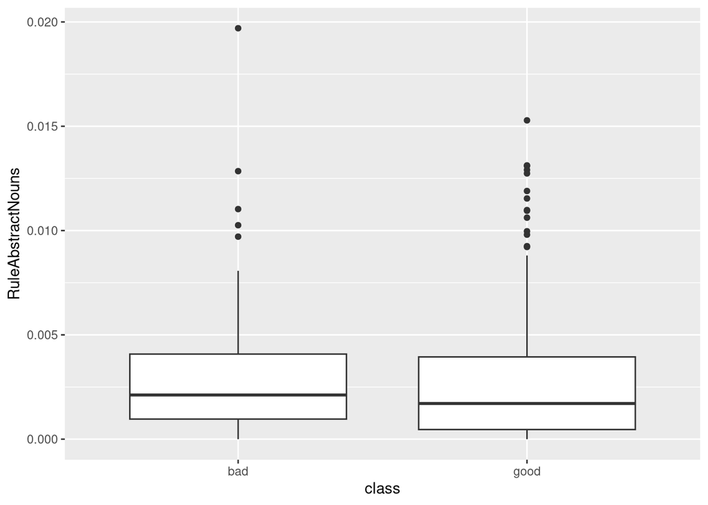

```
## boxplot RuleAnaphoricReferences
```

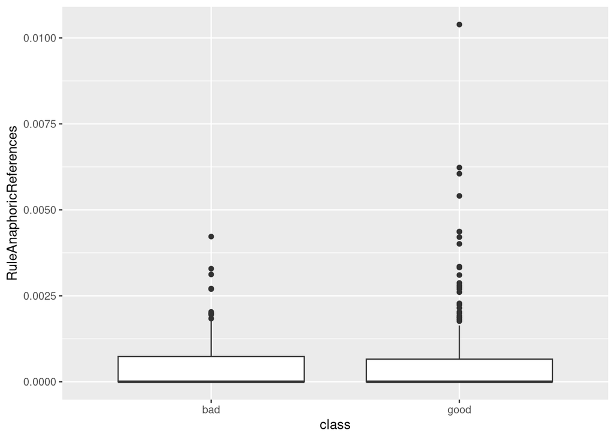

```
## boxplot RuleCaseRepetition.max_repetition_count
```

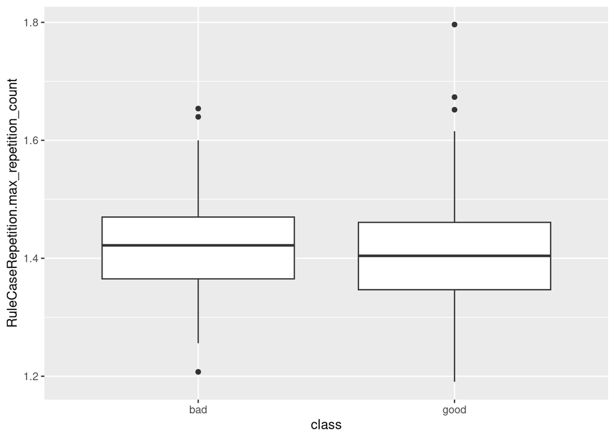

```
## boxplot RuleCaseRepetition.max_repetition_count.v
```

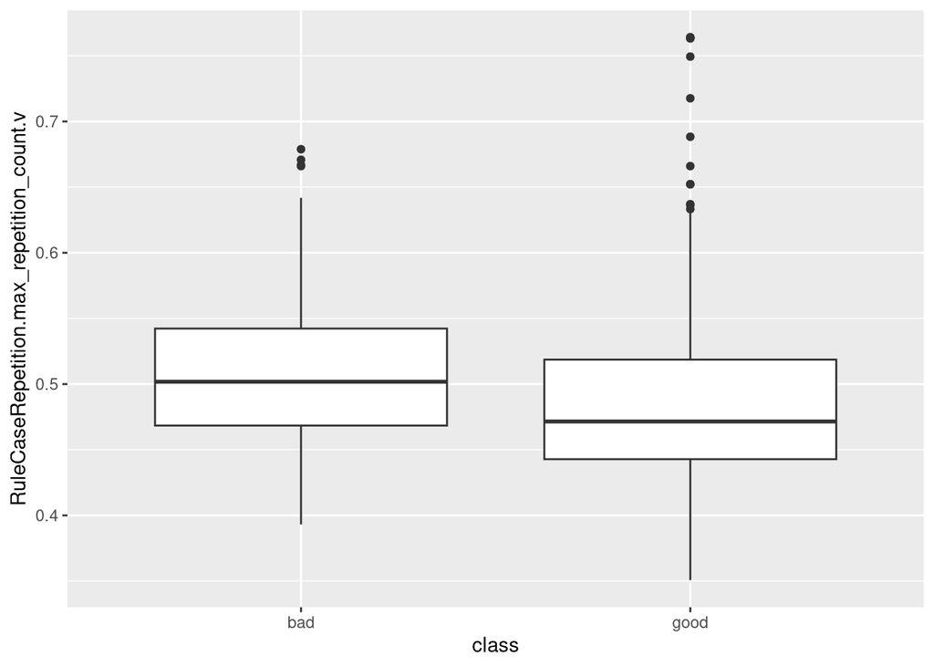

```
## boxplot RuleConfirmationExpressions
```

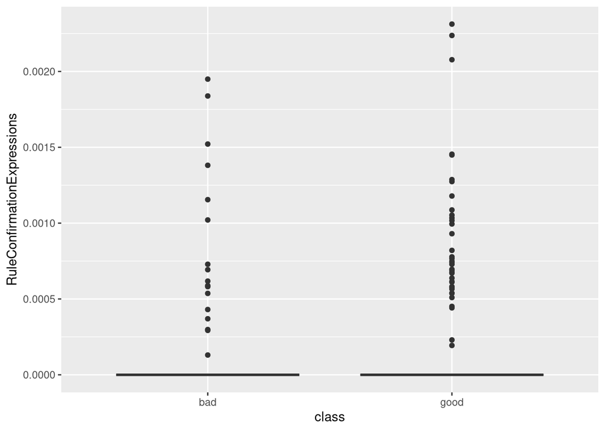

```
## boxplot RuleDoubleAdpos
```

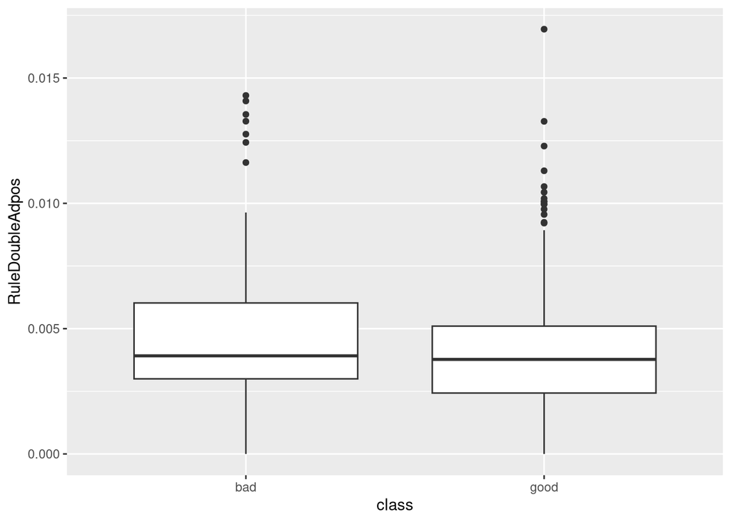

```
## boxplot RuleDoubleAdpos.max_allowable_distance
```

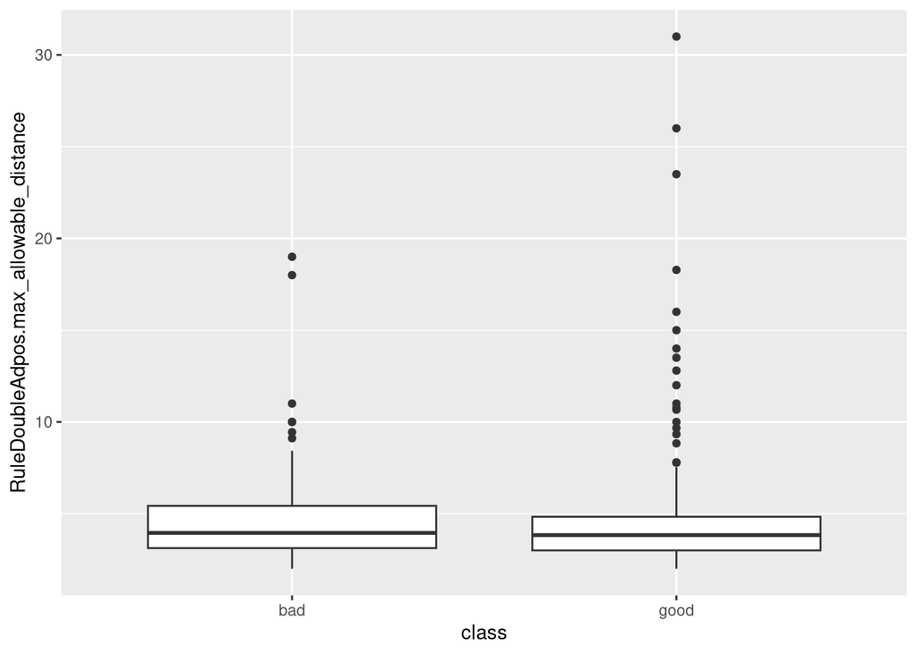

```
## boxplot RuleDoubleAdpos.max_allowable_distance.v
```

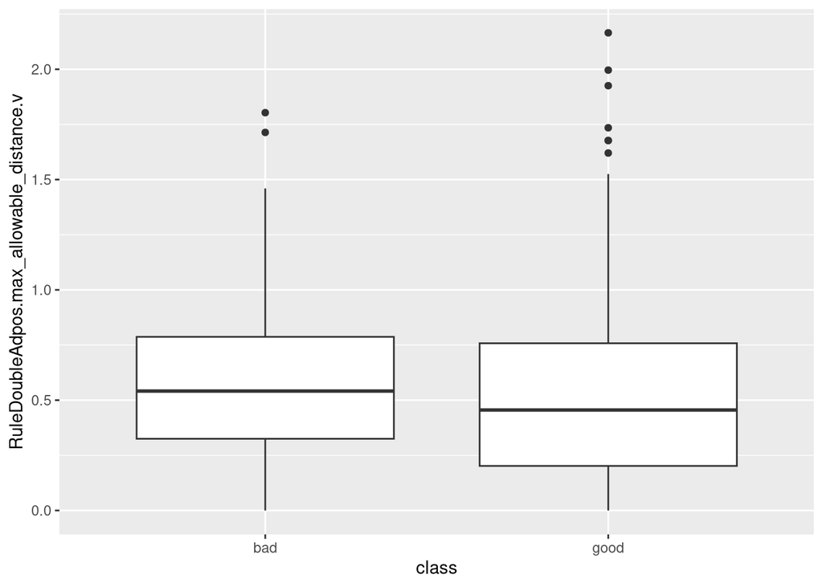

```
## boxplot RuleGPadjective
```

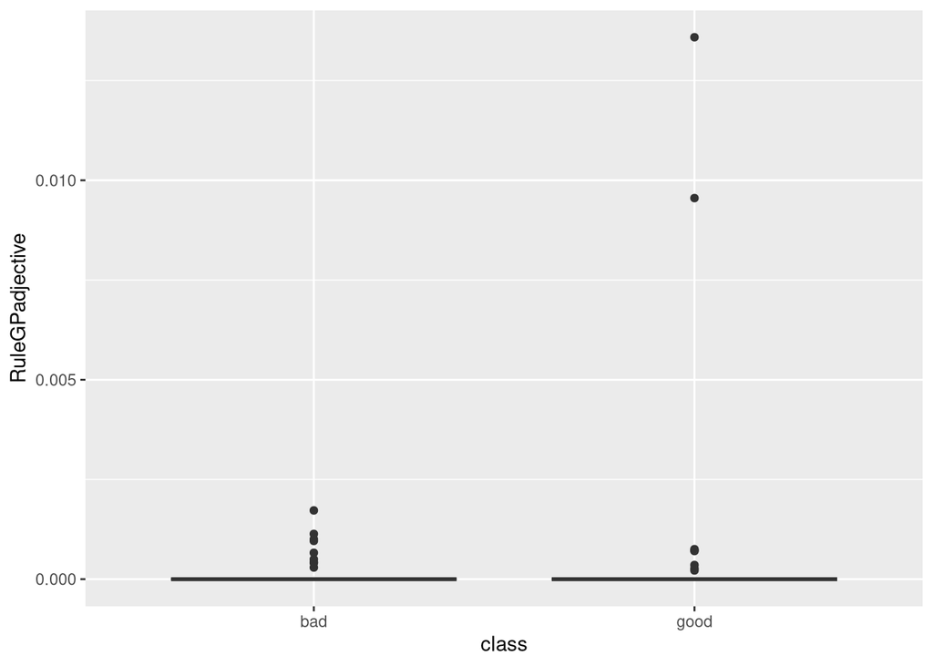

```
## boxplot RuleGPcoordovs
```

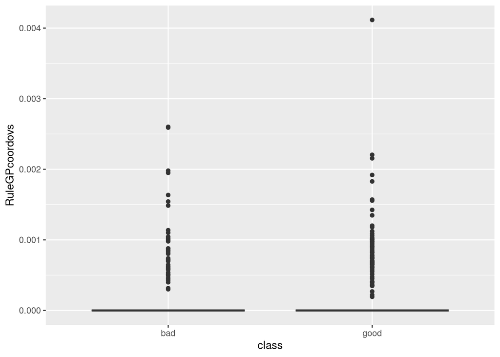

```
## boxplot RuleGPdeverbaddr
```

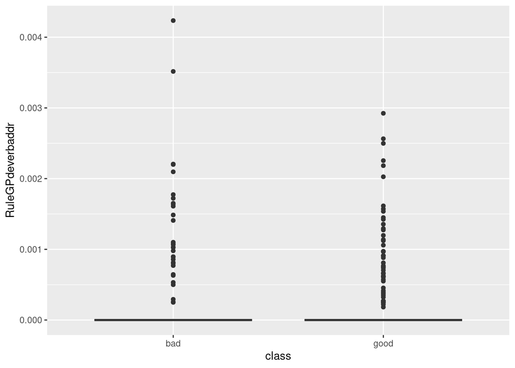

```
## boxplot RuleGPdeverbsubj
```

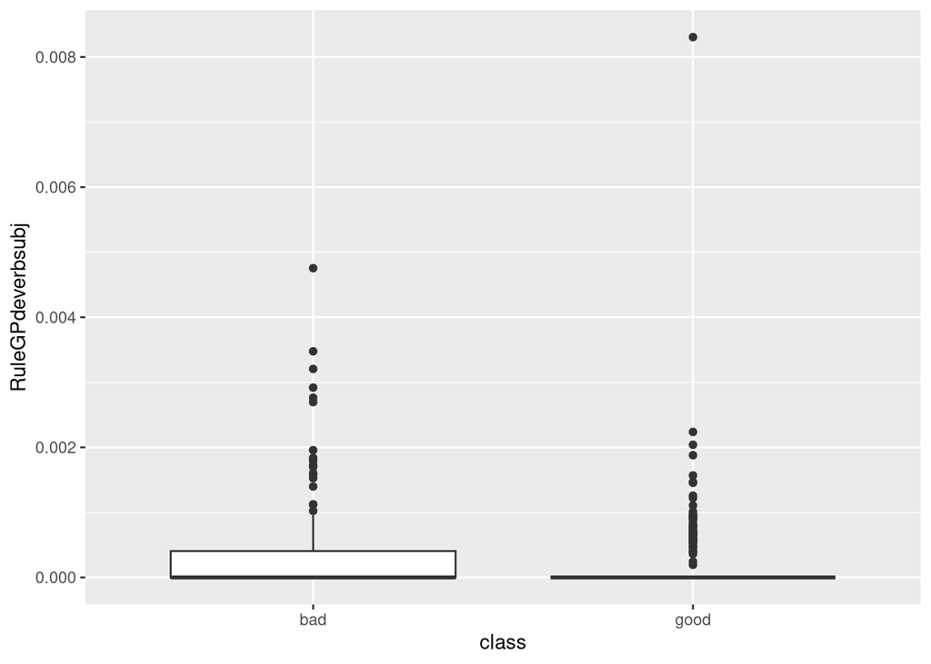

```
## boxplot RuleGPpatbenperson
```

[57 more figures not shown]

```r
for (variab in names(data_clean)[.firstnonmetacolumn:ncol(data_clean)]) {
  cat("boxplot", variab, "\n")
  print(
    data_clean %>% ggplot(aes(x = class, y = !!sym(variab))) +
      geom_boxplot()
  )
}
```

# Parameter borders

```r
parameter_variations <- names(data_clean)[.firstnonmetacolumn:ncol(data_clean)][
  str_ends(names(data_clean)[.firstnonmetacolumn:ncol(data_clean)], "\\.v")
]
parameters <- str_remove(parameter_variations, "\\.v")

data_comb <- data_clean %>% select(KUK_ID, class)

for (p in parameters) {
  combined_df <- data.frame(
    data_clean[[p]] +
      data_clean[[paste0(c(p, ".v"), collapse = "")]] *
        if_else(variable_polarity[p], 0, 1)
  )
  names(combined_df) <- paste0(c(p, ".comb"), collapse = "")

  data_comb <- data_comb %>% bind_cols(combined_df)
}

intervals_comb <- tibble(
  feat = character(),
  type = character(),
  minimum = numeric(),
  maximum = numeric(),
)

for (variab in names(data_comb)[3:ncol(data_comb)]) {
  cat(variab, "\n")

  distr_good <- data_comb %>%
    filter(class == "good") %>%
    pull({{ variab }})
  distr_bad <- data_comb %>%
    filter(class == "bad") %>%
    pull({{ variab }})

  quant_good <- quantile(distr_good, probs = c(0.25, 0.75), names = FALSE)
  quant_bad <- quantile(distr_bad, probs = c(0.25, 0.75), names = FALSE)
  borders <- sort(c(quant_good, quant_bad))[2:3]

  if (
    (quant_good[1] < quant_bad[1] & quant_good[2] > quant_bad[2]) |
      (quant_good[1] > quant_bad[1] & quant_good[2] < quant_bad[2])) {
    cat(variab, "not determinative\n")
  } else if (variable_polarity[str_remove(variab, "\\.comb")]) {
    intervals_comb <- intervals_comb %>%
      add_row(
        feat = variab,
        type = "bad",
        minimum = -Inf,
        maximum = borders[1]
      ) %>%
      add_row(
        feat = variab,
        type = "medium",
        minimum = borders[1],
        maximum = borders[2]
      ) %>%
      add_row(
        feat = variab,
        type = "good",
        minimum = borders[2],
        maximum = Inf
      )
  } else {
    intervals_comb <- intervals_comb %>%
      add_row(
        feat = variab,
        type = "good",
        minimum = -Inf,
        maximum = borders[1]
      ) %>%
      add_row(
        feat = variab,
        type = "medium",
        minimum = borders[1],
        maximum = borders[2]
      ) %>%
      add_row(
        feat = variab,
        type = "bad",
        minimum = borders[2],
        maximum = Inf
      )
  }
}
```

```
## RuleCaseRepetition.max_repetition_count.comb
## RuleDoubleAdpos.max_allowable_distance.comb
## RuleInfVerbDistance.max_distance.comb
## RuleInfVerbDistance.max_distance.comb not determinative
## RuleLongSentences.max_length.comb
## RuleMultiPartVerbs.max_distance.comb
## RuleMultiPartVerbs.max_distance.comb not determinative
## RulePredAtClauseBeginning.max_order.comb
## RulePredAtClauseBeginning.max_order.comb not determinative
## RulePredObjDistance.max_distance.comb
## RulePredSubjDistance.max_distance.comb
## RuleTooFewVerbs.min_verb_frac.comb
## RuleTooManyNegations.max_allowable_negations.comb
## RuleTooManyNegations.max_negation_frac.comb
## RuleTooManyNominalConstructions.max_allowable_nouns.comb
## RuleTooManyNominalConstructions.max_noun_frac.comb
## maentropy.comb
## mattr.comb
```

```r
intervals_comb %>% print(n = 1000)
```

```
## # A tibble: 36 × 4
##    feat                                                 type    minimum  maximum
##    <chr>                                                <chr>     <dbl>    <dbl>
##  1 RuleCaseRepetition.max_repetition_count.comb         good  -Inf        1.85
##  2 RuleCaseRepetition.max_repetition_count.comb         medi…    1.85     1.97
##  3 RuleCaseRepetition.max_repetition_count.comb         bad      1.97   Inf
##  4 RuleDoubleAdpos.max_allowable_distance.comb          good  -Inf        3.58
##  5 RuleDoubleAdpos.max_allowable_distance.comb          medi…    3.58     5.57
##  6 RuleDoubleAdpos.max_allowable_distance.comb          bad      5.57   Inf
##  7 RuleLongSentences.max_length.comb                    good  -Inf       12.0
##  8 RuleLongSentences.max_length.comb                    medi…   12.0     14.7
##  9 RuleLongSentences.max_length.comb                    bad     14.7    Inf
## 10 RulePredObjDistance.max_distance.comb                good  -Inf        2.42
## 11 RulePredObjDistance.max_distance.comb                medi…    2.42     3.04
## 12 RulePredObjDistance.max_distance.comb                bad      3.04   Inf
```

[output cut: 24 more lines]